# Aliasing

```python
import numpy as np
import matplotlib.pyplot as plt
import IPython.display as ipd
import librosa
```

Recall that frequencies are mirror images of each other after roughly $N/2$

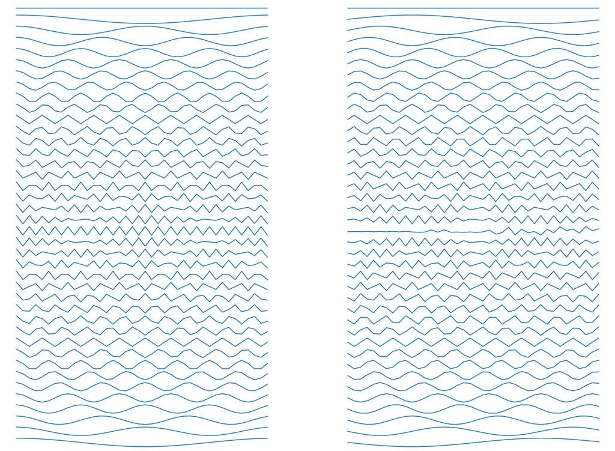

```python
N = 40
plt.figure(figsize=(20, 15))
for k in range(N):
    c = np.cos(2*np.pi*k*np.arange(N)/N)
    s = np.sin(2*np.pi*k*np.arange(N)/N)
    plt.subplot(N, 2, k*2+1)
    plt.plot(c)
    plt.axis('off')
    plt.subplot(N, 2, k*2+2)
    plt.plot(s)
    plt.axis('off')
```

Real part is the same for frequency $k$ and frequency $N-k$, but the imaginary part is the exact negation between frequency $k$ and freuqency $N-k$. What this means is that the coefficients of the complex DFT $X[k]$ and $X[N-k]$ are "complex conjugates" of each other. (Imaginary component gets flipped).

### Aliasing

Furthermore, if we're trying to represent frequencies that are beyond half the sample rate, then they get "aliased" (mistaken for) lower frequencies

[figure not shown]

Let's look at an example of what happens when we generate a square wave and don't take enough samples. Originally, we're OK and we see all of the harmonics

[interactive chart not shown]

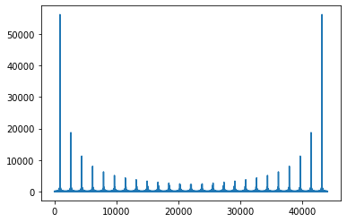

```python
sr = 44100
t = np.arange(sr*2)/sr
f = 880
x = np.sign(np.sin(2*np.pi*f*t))
plt.plot(np.arange(len(x))*(sr)/len(x), np.abs(np.fft.fft(x)))
ipd.Audio(x, rate=int(sr))
```

But if we drop the sample rate by a factor of 6, then some of the higher harmonics get aliased. We even hear some of them in the bass region below the fundamental frequency

[interactive chart not shown]

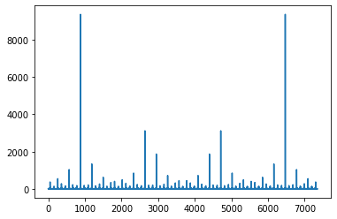

```python
fac = 6
y = x[0::fac]
plt.plot(np.arange(len(y))*(sr/fac)/len(y), np.abs(np.fft.fft(y)))
ipd.Audio(y, rate=int(sr/fac))
```

The same sort of thing can happen with audio, which leads towards a very strange effect when we pass through the **Nyquist rate** (half of the sample rate). Any frequency that is beyond the Nyquist rate is going to to alias if we don't properly filter it out before we sample

```python
x, sr = librosa.load("real.mp3", 22050)
ipd.Audio(x, rate=sr)
```

[interactive chart not shown]

```python
y = x[0::fac]
ipd.Audio(y, rate=int(sr/fac))
```

[interactive chart not shown]